# Smart Parking Availability Prediction and Compliance Risk Mapping

## Melbourne CBD — Project 22A | Chameleon Company

In this notebook we are building an end-to-end data science pipeline to analyse parking utilization across Melbourne's CBD. The goal is to identify which parking bays and zones carry the highest compliance risk which means they are most likely to cause confusion or fines for drivers due to complex restrictions and high occupancy. We will work through data cleaning, feature engineering, risk scoring, machine learning, and spatial mapping to produce something that is actually useful for real world parking management decisions.

```python
import pandas as pd
import numpy as np
import matplotlib.pyplot as plt
import matplotlib.ticker as mtick
import seaborn as sns
import warnings
warnings.filterwarnings('ignore')

print("Libraries loaded successfully")
```

```
Libraries loaded successfully
```

## Loading Our Datasets

We are loading all the datasets sourced from the City of Melbourne open data portal. These cover real time sensor occupancy readings, parking restrictions, bay locations, sign plates, and off street car parks. We will do a quick audit of each dataset first before any cleaning so we know exactly what we are working with.

```python
base = r"MOP-Code"

sensors      = pd.read_csv(f"{base}/datascience/usecases/DEPENDENCIES/Project-22-A-Raw-Data/Raw-Data/on-street-parking-bay-sensors.csv")
bays         = pd.read_csv(f"{base}/datascience/usecases/DEPENDENCIES/Project-22-A-Raw-Data/Raw-Data/on-street-parking-bays.csv")
restrictions = pd.read_csv(f"{base}/datascience/usecases/DEPENDENCIES/Project-22-A-Raw-Data/Raw-Data/on-street-car-park-bay-restrictions.csv")
signplates   = pd.read_csv(f"{base}/datascience/usecases/DEPENDENCIES/Project-22-A-Raw-Data/Raw-Data/sign-plates-located-in-each-parking-zone.csv")
offstreet    = pd.read_csv(f"{base}/datascience/usecases/DEPENDENCIES/Project-22-A-Raw-Data/Raw-Data/off-street-car-parks-with-capacity-and-type.csv")

datasets = {
    'sensors': sensors,
    'bays': bays,
    'restrictions': restrictions,
    'signplates': signplates,
    'offstreet': offstreet
}

for name, df in datasets.items():
    print(f"\n{'='*40}")
    print(f"{name.upper()} — Shape: {df.shape}")
    print(f"Columns: {df.columns.tolist()}")
    print(f"Nulls:\n{df.isnull().sum()}")
```

```
========================================
SENSORS — Shape: (3309, 6)
Columns: ['Lastupdated', 'Status_Timestamp', 'Zone_Number', 'Status_Description', 'KerbsideID', 'Location']
Nulls:
Lastupdated             0
Status_Timestamp        0
Zone_Number           218
Status_Description      0
KerbsideID              0
Location                0
dtype: int64

========================================
BAYS — Shape: (23864, 7)
Columns: ['RoadSegmentID', 'KerbsideID', 'RoadSegmentDescription', 'Latitude', 'Longitude', 'LastUpdated', 'Location']
Nulls:
RoadSegmentID                 0
KerbsideID                18525
RoadSegmentDescription        0
Latitude                      0
Longitude                     0
LastUpdated                   0
Location                      0
dtype: int64

========================================
RESTRICTIONS — Shape: (4263, 62)
Columns: ['BayID', 'DeviceID', 'Description1', 'Description2', 'Description3', 'Description4', 'Description5', 'Description6', 'DisabilityExt1', 'DisabilityExt2', 'DisabilityExt3', 'DisabilityExt4', 'DisabilityExt5', 'DisabilityExt6', 'Duration1', 'Duration2', 'Duration3', 'Duration4', 'Duration5', …
Nulls:
BayID              0
DeviceID           0
Description1       0
Description2    1401
Description3    3679
                ...
TypeDesc2       1401
TypeDesc3       3679
TypeDesc4       4046
TypeDesc5       4181
TypeDesc6       4236
```

[output cut: 14 more lines]

```
OFFSTREET — Shape: (151199, 11)
Columns: ['Census year', 'Block ID', 'Property ID', 'Base property ID', 'Building address', 'CLUE small area', 'Parking type', 'Parking spaces', 'Longitude', 'Latitude', 'location']
Nulls:
Census year            0
Block ID               0
Property ID            0
Base property ID       0
Building address       0
CLUE small area        0
Parking type           0
Parking spaces         0
Longitude           1084
Latitude            1084
location            1084
dtype: int64
```

## Cleaning Our Sensor Data

The sensor dataset is the heart of this project. We are converting timestamps to proper datetime format, creating a binary occupied column, and extracting time based features like hour, day of week, and month that will be important for the model later.

```python
# Cleaning our sensor data
sensors['zone_missing'] = sensors['Zone_Number'].isnull().astype(int)
sensors['Status_Timestamp'] = pd.to_datetime(sensors['Status_Timestamp'], utc=True)
sensors['Lastupdated'] = pd.to_datetime(sensors['Lastupdated'], utc=True)
sensors['occupied'] = (sensors['Status_Description'] == 'Present').astype(int)
sensors['hour'] = sensors['Status_Timestamp'].dt.hour
sensors['day_of_week'] = sensors['Status_Timestamp'].dt.dayofweek
sensors['month'] = sensors['Status_Timestamp'].dt.month
sensors['is_weekend'] = (sensors['day_of_week'] >= 5).astype(int)

print(f"Sensors cleaned: {sensors.shape}")
print(f"Occupied: {sensors['occupied'].sum()} | Unoccupied: {(sensors['occupied']==0).sum()}")
print(sensors[['Status_Timestamp','hour','day_of_week','occupied','is_weekend']].head())
```

```
Sensors cleaned: (3309, 12)
Occupied: 1710 | Unoccupied: 1599
           Status_Timestamp  hour  day_of_week  occupied  is_weekend
0 2024-05-03 02:55:43+00:00     2            4         0           0
1 2024-10-11 04:06:49+00:00     4            4         0           0
2 2024-10-01 23:22:55+00:00    23            1         1           0
3 2024-10-01 22:50:25+00:00    22            1         0           0
4 2024-10-01 22:48:56+00:00    22            1         0           0
```

## Cleaning Our Bays Data

```python
# Cleaning our bays data
bays_clean = bays.dropna(subset=['KerbsideID']).copy()
bays_clean['KerbsideID'] = pd.to_numeric(bays_clean['KerbsideID'], errors='coerce')
bays_clean = bays_clean.dropna(subset=['KerbsideID'])
bays_clean['KerbsideID'] = bays_clean['KerbsideID'].astype(int)

print(f"Bays with valid KerbsideID: {bays_clean.shape[0]}")
print(bays_clean.isnull().sum())
```

```
Bays with valid KerbsideID: 5337
RoadSegmentID             0
KerbsideID                0
RoadSegmentDescription    0
Latitude                  0
Longitude                 0
LastUpdated               0
Location                  0
dtype: int64
```

## Cleaning Our Restrictions Data

The restrictions dataset has up to 6 restriction slots per bay. We are using these to build two useful features — restriction complexity which counts how many overlapping rules each bay has, and max stay minutes which tells us the longest allowed stay. These will be key inputs to the compliance risk score later.

```python
# Cleaning our restrictions data and building complexity score
desc_cols = ['Description1','Description2','Description3',
             'Description4','Description5','Description6']
restrictions['restriction_complexity'] = restrictions[desc_cols].notnull().sum(axis=1)

dur_cols = ['Duration1','Duration2','Duration3',
            'Duration4','Duration5','Duration6']
restrictions['max_stay_minutes'] = restrictions[dur_cols].max(axis=1)

restrictions_clean = restrictions[['BayID','restriction_complexity',
                                   'max_stay_minutes','TypeDesc1']].copy()

print(f"Restrictions cleaned: {restrictions_clean.shape}")
print(f"\nComplexity distribution:")
print(restrictions_clean['restriction_complexity'].value_counts())
print(f"\nMax stay minutes stats:")
print(restrictions_clean['max_stay_minutes'].describe())
```

```
Restrictions cleaned: (4263, 4)

Complexity distribution:
restriction_complexity
2    2278
1    1401
3     367
4     135
5      57
6      25
Name: count, dtype: int64

Max stay minutes stats:
count    4263.000000
mean      139.195168
std       143.597198
min         2.000000
25%       120.000000
50%       120.000000
75%       120.000000
max      1440.000000
Name: max_stay_minutes, dtype: float64
```

## Cleaning Our Sign Plates Data

The sign plates dataset tells us the restriction hours and rules per parking zone. We are parsing the start and finish times, calculating how long each restriction window is in hours, and aggregating to one row per zone so we can join it cleanly to the master dataset later without causing row duplication.

```python
# Cleaning our sign plates data
signplates['Time_Restrictions_Start'] = pd.to_datetime(
    signplates['Time_Restrictions_Start'], format='%H:%M:%S').dt.time
signplates['Time_Restrictions_Finish'] = pd.to_datetime(
    signplates['Time_Restrictions_Finish'], format='%H:%M:%S').dt.time

signplates['restriction_hours'] = (
    pd.to_datetime(signplates['Time_Restrictions_Finish'].astype(str)) -
    pd.to_datetime(signplates['Time_Restrictions_Start'].astype(str))
).dt.seconds / 3600

signplates_agg = signplates.groupby('ParkingZone').agg(
    avg_restriction_hours=('restriction_hours','mean'),
    max_restriction_hours=('restriction_hours','max'),
    num_restriction_rules=('Restriction_Display','count')
).reset_index()

print(f"Signplates aggregated: {signplates_agg.shape}")
print(signplates_agg.describe())
```

```
Signplates aggregated: (757, 4)
       ParkingZone  avg_restriction_hours  max_restriction_hours  \
count   757.000000             757.000000             757.000000
mean   7516.738441               8.924794              13.139366
std     287.823056               1.766000               2.170188
min    7000.000000               3.375000               5.000000
25%    7258.000000               7.500000              11.000000
50%    7534.000000               8.000000              15.000000
75%    7765.000000              10.000000              15.000000
max    7998.000000              15.500000              15.500000

       num_restriction_rules
count             757.000000
mean                2.685601
std                 1.199191
min                 1.000000
25%                 2.000000
50%                 3.000000
75%                 4.000000
max                 8.000000
```

## Cleaning Our Off Street Car Parks Data

```python
# Cleaning our off street car parks data
offstreet_clean = offstreet.dropna(subset=['Latitude','Longitude']).copy()
offstreet_clean = offstreet_clean.sort_values('Census year', ascending=False)
offstreet_clean = offstreet_clean.drop_duplicates(subset=['Property ID'], keep='first')

print(f"Offstreet cleaned: {offstreet_clean.shape}")
print(offstreet_clean['Parking type'].value_counts())
print(f"\nTotal parking spaces: {offstreet_clean['Parking spaces'].sum():,}")
```

```
Offstreet cleaned: (7839, 11)
Parking type
Residential    5556
Private        2099
Commercial      184
Name: count, dtype: int64

Total parking spaces: 233,406
```

## Building Our Master Dataset

Now that all datasets are cleaned we are joining them together into a single master dataframe. We link sensors to bays on KerbsideID to get coordinates, then join restrictions and sign plates to bring in the compliance related features. This master dataset is what everything else is built on.

```python
# Joining sensors to bays to get coordinates
master = sensors.merge(
    bays_clean[['KerbsideID','Latitude','Longitude','RoadSegmentDescription']],
    on='KerbsideID', how='left'
)
print(f"After joining bays: {master.shape}")
print(f"Coordinate nulls: {master['Latitude'].isnull().sum()}")

# Drop duplicates and rows without coordinates
master = master.drop_duplicates(subset=['KerbsideID','Status_Timestamp'], keep='first')
master = master.dropna(subset=['Latitude','Longitude'])
print(f"After dedup and dropping null coords: {master.shape}")
```

```
After joining bays: (3322, 15)
Coordinate nulls: 100
After dedup and dropping null coords: (3209, 15)
```

## Joining Restrictions and Sign Plates

Now we are bringing in the restriction features. Since the KerbsideID and BayID systems do not match perfectly we join restrictions on the 72 bays that do match, and fill the rest using zone level sign plate data. This gives us restriction complexity and enforcement hours across all 3,209 bays.

```python
# Joining sign plates on Zone_Number
master = master.merge(
    signplates_agg,
    left_on='Zone_Number', right_on='ParkingZone', how='left'
)

# Fix any row explosion from the join
master = master.drop_duplicates(subset=['KerbsideID'], keep='first')

# Fill nulls with median for unmatched zones
master['avg_restriction_hours'] = master['avg_restriction_hours'].fillna(
    master['avg_restriction_hours'].median())
master['max_restriction_hours'] = master['max_restriction_hours'].fillna(
    master['max_restriction_hours'].median())
master['num_restriction_rules'] = master['num_restriction_rules'].fillna(
    master['num_restriction_rules'].median())

# Join restrictions on the 72 matching bays
master = master.merge(
    restrictions_clean[['BayID','restriction_complexity','max_stay_minutes']],
    left_on='KerbsideID', right_on='BayID', how='left'
)
master['restriction_complexity'] = master['restriction_complexity'].fillna(1)
master['max_stay_minutes'] = master['max_stay_minutes'].fillna(
    master['max_stay_minutes'].median())
master = master.drop(columns=['BayID'], errors='ignore')

print(f"Master shape: {master.shape}")
print(master.isnull().sum())
```

```
Master shape: (3209, 21)
Lastupdated                 0
Status_Timestamp            0
Zone_Number               207
Status_Description          0
KerbsideID                  0
Location                    0
zone_missing                0
occupied                    0
hour                        0
day_of_week                 0
month                       0
is_weekend                  0
Latitude                    0
Longitude                   0
RoadSegmentDescription      0
ParkingZone               230
avg_restriction_hours       0
max_restriction_hours       0
num_restriction_rules       0
restriction_complexity      0
max_stay_minutes            0
dtype: int64
```

## Adding Public Holidays

We are adding a Victorian public holiday flag to the master dataset. Parking behaviour on public holidays is quite different from regular weekdays and is an important signal for the model.

```python
# Adding Victorian public holidays
!pip install holidays -q

import holidays

vic_holidays = holidays.Australia(state='VIC', years=[2024, 2025])
master['is_public_holiday'] = master['Status_Timestamp'].dt.date.apply(
    lambda x: 1 if x in vic_holidays else 0)

print(f"Public holidays flagged: {master['is_public_holiday'].sum()}")
print(f"Master shape: {master.shape}")
print("Master dataset ready")
```

```
Public holidays flagged: 61
Master shape: (3209, 22)
Master dataset ready
```

## Exploratory Data Analysis

Before jumping into modelling we want to understand what our data is actually telling us. In this section we are producing key visualisations that reveal occupancy patterns across different times of day, days of the week, and day types. These charts form the KPI layer of our project and directly inform the compliance risk framework we will build next.

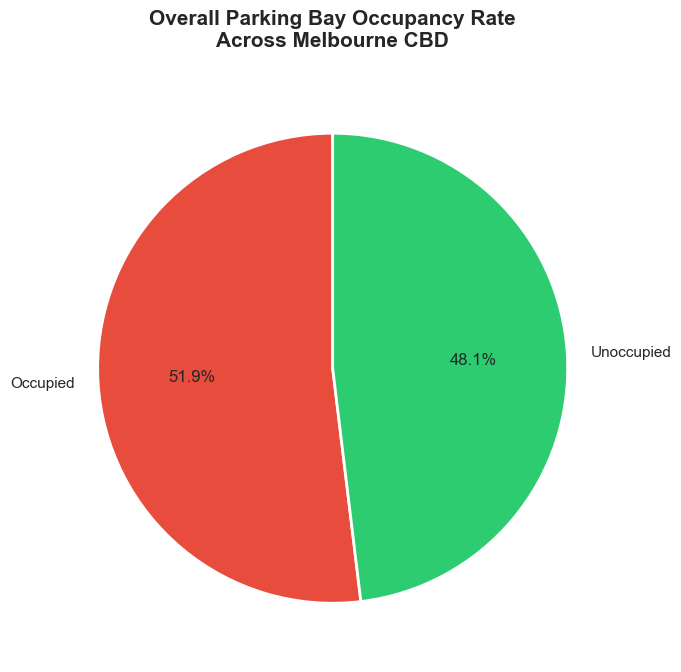

```
Overall occupancy rate: 51.9%
```

```python
# Setting up our visualisation environment
sns.set_theme(style='darkgrid')
plt.rcParams['figure.figsize'] = (12, 6)
plt.rcParams['font.size'] = 12

# KPI 1 — Overall occupancy rate
occupancy_rate = master['occupied'].mean() * 100
unoccupied_rate = 100 - occupancy_rate

fig, ax = plt.subplots(figsize=(7, 7))
ax.pie([occupancy_rate, unoccupied_rate],
       labels=['Occupied', 'Unoccupied'],
       autopct='%1.1f%%',
       colors=['#e74c3c', '#2ecc71'],
       startangle=90,
       wedgeprops={'edgecolor': 'white', 'linewidth': 2})
ax.set_title('Overall Parking Bay Occupancy Rate\nAcross Melbourne CBD',
             fontsize=15, fontweight='bold', pad=20)
plt.tight_layout()
plt.show()
print(f"Overall occupancy rate: {occupancy_rate:.1f}%")
```

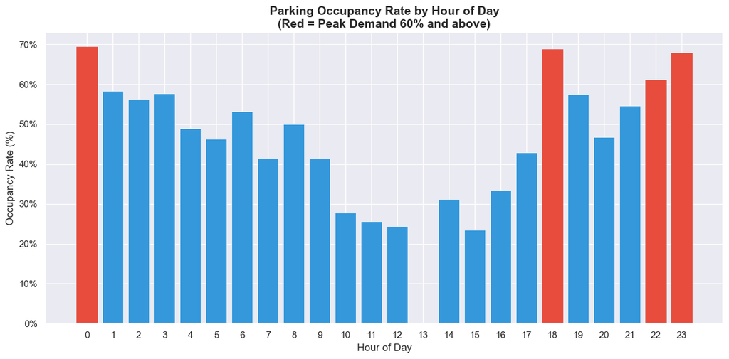

```python
# KPI 2 — Occupancy by hour of day
hourly_occ = master.groupby('hour')['occupied'].mean() * 100

fig, ax = plt.subplots()
bars = ax.bar(hourly_occ.index, hourly_occ.values,
              color='#3498db', edgecolor='white', linewidth=0.5)

for i, bar in enumerate(bars):
    if hourly_occ.values[i] >= 60:
        bar.set_color('#e74c3c')

ax.set_xlabel('Hour of Day', fontsize=12)
ax.set_ylabel('Occupancy Rate (%)', fontsize=12)
ax.set_title('Parking Occupancy Rate by Hour of Day\n(Red = Peak Demand 60% and above)',
             fontsize=14, fontweight='bold')
ax.yaxis.set_major_formatter(mtick.PercentFormatter())
ax.set_xticks(range(0, 24))
plt.tight_layout()
plt.show()
```

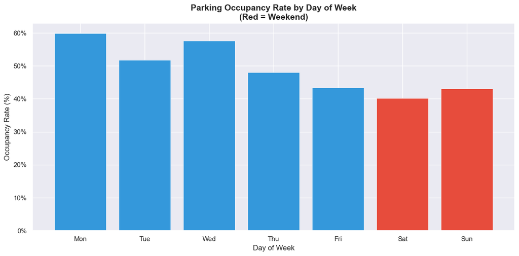

```python
# KPI 3 — Occupancy by day of week
day_labels = ['Mon', 'Tue', 'Wed', 'Thu', 'Fri', 'Sat', 'Sun']
daily_occ = master.groupby('day_of_week')['occupied'].mean() * 100

fig, ax = plt.subplots()
colors = ['#e74c3c' if i >= 5 else '#3498db' for i in range(7)]
ax.bar(day_labels, daily_occ.values, color=colors, edgecolor='white', linewidth=0.5)
ax.set_xlabel('Day of Week', fontsize=12)
ax.set_ylabel('Occupancy Rate (%)', fontsize=12)
ax.set_title('Parking Occupancy Rate by Day of Week\n(Red = Weekend)',
             fontsize=14, fontweight='bold')
ax.yaxis.set_major_formatter(mtick.PercentFormatter())
plt.tight_layout()
plt.show()
```

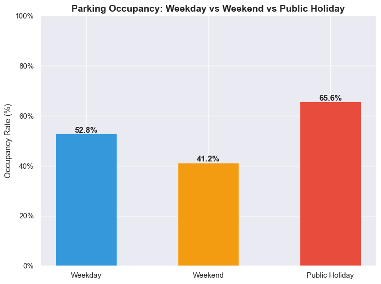

```python
# KPI 4 — Weekday vs Weekend vs Public Holiday
values = [
    master[(master['is_public_holiday']==0) & (master['is_weekend']==0)]['occupied'].mean() * 100,
    master[(master['is_public_holiday']==0) & (master['is_weekend']==1)]['occupied'].mean() * 100,
    master[master['is_public_holiday']==1]['occupied'].mean() * 100
]
labels = ['Weekday', 'Weekend', 'Public Holiday']

fig, ax = plt.subplots(figsize=(8, 6))
bars = ax.bar(labels, values, color=['#3498db','#f39c12','#e74c3c'],
              edgecolor='white', linewidth=0.5, width=0.5)
for bar, val in zip(bars, values):
    ax.text(bar.get_x() + bar.get_width()/2, bar.get_height() + 0.5,
            f'{val:.1f}%', ha='center', fontsize=12, fontweight='bold')
ax.set_ylabel('Occupancy Rate (%)', fontsize=12)
ax.set_title('Parking Occupancy: Weekday vs Weekend vs Public Holiday',
             fontsize=14, fontweight='bold')
ax.yaxis.set_major_formatter(mtick.PercentFormatter())
ax.set_ylim(0, 100)
plt.tight_layout()
plt.show()
```

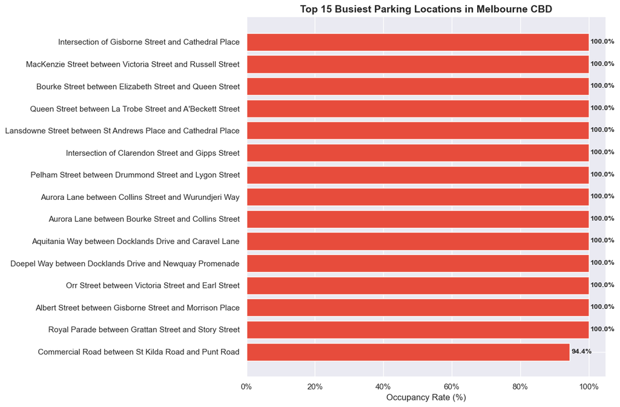

```python
# KPI 5 — Top 15 busiest road segments
top_roads = master.groupby('RoadSegmentDescription')['occupied'].mean().sort_values(
    ascending=False).head(15) * 100

fig, ax = plt.subplots(figsize=(12, 8))
bars = ax.barh(top_roads.index, top_roads.values, color='#e74c3c', edgecolor='white')
for bar, val in zip(bars, top_roads.values):
    ax.text(bar.get_width() + 0.5, bar.get_y() + bar.get_height()/2,
            f'{val:.1f}%', va='center', fontsize=10, fontweight='bold')
ax.set_xlabel('Occupancy Rate (%)', fontsize=12)
ax.set_title('Top 15 Busiest Parking Locations in Melbourne CBD',
             fontsize=14, fontweight='bold')
ax.xaxis.set_major_formatter(mtick.PercentFormatter())
ax.invert_yaxis()
plt.tight_layout()
plt.show()
```

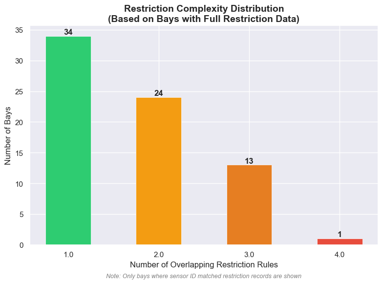

```
Bays with real restriction data: 72
```

```python
# KPI 6 — Restriction complexity distribution
real_restrictions = master[master['KerbsideID'].isin(restrictions_clean['BayID'])]
complexity_counts = real_restrictions['restriction_complexity'].value_counts().sort_index()

fig, ax = plt.subplots(figsize=(8, 6))
colors = ['#2ecc71','#f39c12','#e67e22','#e74c3c']
bars = ax.bar(complexity_counts.index.astype(str), complexity_counts.values,
              color=colors[:len(complexity_counts)], edgecolor='white', linewidth=0.5, width=0.5)

for bar, val in zip(bars, complexity_counts.values):
    ax.text(bar.get_x() + bar.get_width()/2, bar.get_height() + 0.3,
            str(val), ha='center', fontsize=12, fontweight='bold')

ax.set_xlabel('Number of Overlapping Restriction Rules', fontsize=12)
ax.set_ylabel('Number of Bays', fontsize=12)
ax.set_title('Restriction Complexity Distribution\n(Based on Bays with Full Restriction Data)',
             fontsize=14, fontweight='bold')
ax.annotate('Note: Only bays where sensor ID matched restriction records are shown',
            xy=(0.5, -0.15), xycoords='axes fraction', ha='center',
            fontsize=9, color='grey', style='italic')
plt.tight_layout()
plt.show()
print(f"Bays with real restriction data: {len(real_restrictions)}")
```

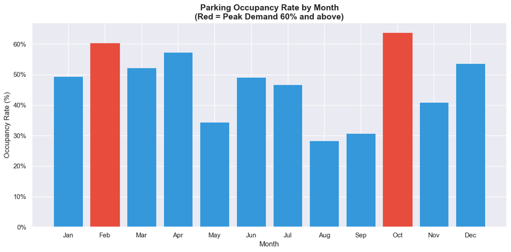

```python
# KPI 7 — Occupancy by month
month_labels = ['Jan','Feb','Mar','Apr','May','Jun',
                'Jul','Aug','Sep','Oct','Nov','Dec']
monthly_occ = master.groupby('month')['occupied'].mean() * 100

fig, ax = plt.subplots()
bars = ax.bar(monthly_occ.index, monthly_occ.values,
              color='#3498db', edgecolor='white', linewidth=0.5)

for bar, val in zip(bars, monthly_occ.values):
    if val >= 60:
        bar.set_color('#e74c3c')

ax.set_xlabel('Month', fontsize=12)
ax.set_ylabel('Occupancy Rate (%)', fontsize=12)
ax.set_title('Parking Occupancy Rate by Month\n(Red = Peak Demand 60% and above)',
             fontsize=14, fontweight='bold')
ax.yaxis.set_major_formatter(mtick.PercentFormatter())
ax.set_xticks(monthly_occ.index)
ax.set_xticklabels([month_labels[m-1] for m in monthly_occ.index])
plt.tight_layout()
plt.show()
```

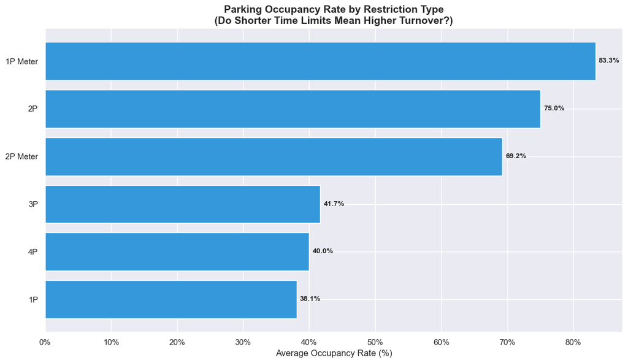

```python
# KPI 8 — Occupancy rate by restriction type
restriction_occ = master.merge(
    restrictions_clean[['BayID','TypeDesc1']],
    left_on='KerbsideID', right_on='BayID', how='left'
)
restriction_occ = restriction_occ.dropna(subset=['TypeDesc1'])
type_occ = restriction_occ.groupby('TypeDesc1')['occupied'].agg(
    ['mean','count']).reset_index()
type_occ.columns = ['Restriction_Type','avg_occupancy','count']
type_occ = type_occ[type_occ['count'] >= 3]
type_occ = type_occ.sort_values('avg_occupancy', ascending=False)
type_occ['avg_occupancy_pct'] = type_occ['avg_occupancy'] * 100

fig, ax = plt.subplots(figsize=(12, 7))
bars = ax.barh(type_occ['Restriction_Type'], type_occ['avg_occupancy_pct'],
               color='#3498db', edgecolor='white')

for bar, val in zip(bars, type_occ['avg_occupancy_pct']):
    ax.text(bar.get_width() + 0.5, bar.get_y() + bar.get_height()/2,
            f'{val:.1f}%', va='center', fontsize=10, fontweight='bold')

ax.set_xlabel('Average Occupancy Rate (%)', fontsize=12)
ax.set_title('Parking Occupancy Rate by Restriction Type\n(Do Shorter Time Limits Mean Higher Turnover?)',
             fontsize=14, fontweight='bold')
ax.xaxis.set_major_formatter(mtick.PercentFormatter())
ax.invert_yaxis()
plt.tight_layout()
plt.show()
```

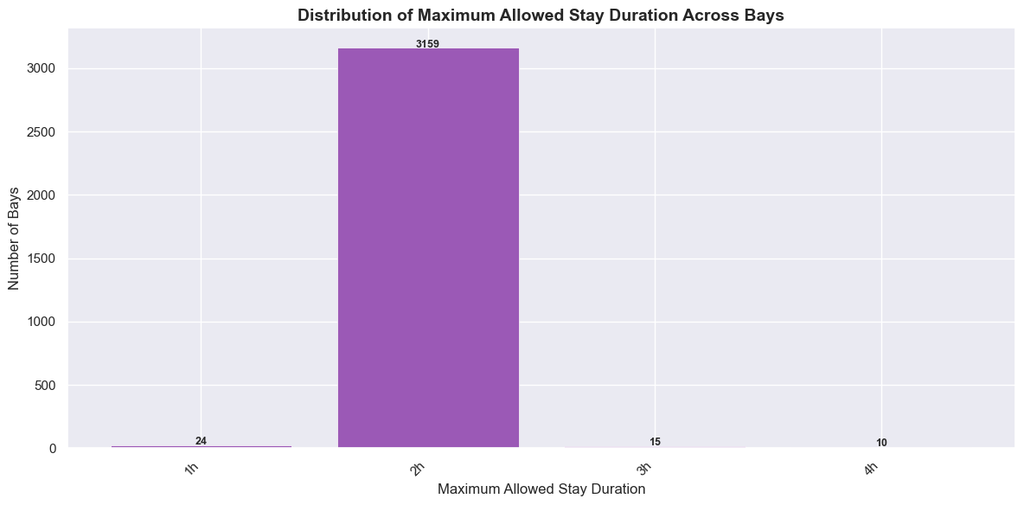

```python
# KPI 9 — Distribution of max stay duration
stay_counts = master['max_stay_minutes'].value_counts().sort_index()
stay_counts = stay_counts[stay_counts.index <= 480]
stay_labels = [f"{int(m//60)}h" if m >= 60 else f"{int(m)}min" for m in stay_counts.index]

fig, ax = plt.subplots(figsize=(12, 6))
bars = ax.bar(range(len(stay_counts)), stay_counts.values,
              color='#9b59b6', edgecolor='white', linewidth=0.5)

for bar, val in zip(bars, stay_counts.values):
    ax.text(bar.get_x() + bar.get_width()/2, bar.get_height() + 5,
            str(val), ha='center', fontsize=9, fontweight='bold')

ax.set_xticks(range(len(stay_counts)))
ax.set_xticklabels(stay_labels, rotation=45, ha='right')
ax.set_xlabel('Maximum Allowed Stay Duration', fontsize=12)
ax.set_ylabel('Number of Bays', fontsize=12)
ax.set_title('Distribution of Maximum Allowed Stay Duration Across Bays',
             fontsize=14, fontweight='bold')
plt.tight_layout()
plt.show()
```

## A Note on the Hour of Day Chart

There is a visible gap at hour 13 (1pm) in the occupancy by hour chart. This is not an error. It simply means no sensor readings were recorded at that specific hour in our dataset. This is because our sensor data is a snapshot of each bay's last known status rather than a continuous time series feed. Some hours naturally have very few or no readings depending on when sensors last updated. Hours between 13:00 and 17:00 generally have low reading counts which makes those bars less statistically reliable. We have kept them visible for transparency but they should be interpreted with caution. This is a known limitation of the dataset and something we would address with a continuous sensor feed in a future version of this project.

## Building Our Compliance Risk Score

This is the core of our project. We are assigning each parking bay a compliance risk score based on how likely it is to cause confusion or fines for drivers. The score is built from four features — restriction complexity, max stay duration, average restriction hours, and number of restriction rules — normalised and weighted to produce a value between 0 and 1. We then classify each bay into Low, Medium, or High risk using percentile based thresholds to ensure a realistic spread across all three categories.

```python
# Building our compliance risk score
from sklearn.preprocessing import MinMaxScaler

scaler = MinMaxScaler()

risk_features = ['restriction_complexity', 'max_stay_minutes',
                 'avg_restriction_hours', 'num_restriction_rules']

master_risk = master.copy()
master_risk[risk_features] = scaler.fit_transform(master_risk[risk_features])

master_risk['compliance_risk_score'] = (
    master_risk['restriction_complexity']  * 0.35 +
    master_risk['avg_restriction_hours']   * 0.30 +
    master_risk['num_restriction_rules']   * 0.20 +
    master_risk['max_stay_minutes']        * 0.15
)

low_thresh = master_risk['compliance_risk_score'].quantile(0.33)
high_thresh = master_risk['compliance_risk_score'].quantile(0.66)

master_risk['risk_category'] = pd.cut(
    master_risk['compliance_risk_score'],
    bins=[0, low_thresh, high_thresh, 1.0],
    labels=['Low', 'Medium', 'High'],
    include_lowest=True
)

print(master_risk['risk_category'].value_counts())
print(f"\nRisk score stats:")
print(master_risk['compliance_risk_score'].describe())
```

```
risk_category
Medium    1760
Low       1120
High       329
Name: count, dtype: int64

Risk score stats:
count    3209.000000
mean        0.200469
std         0.042744
min         0.063665
25%         0.189419
50%         0.192437
75%         0.224228
max         0.574228
Name: compliance_risk_score, dtype: float64
```

## Training Our Machine Learning Model

Now that we have our compliance risk scores and categories we are ready to build the classification model. We are using a Random Forest classifier to predict whether a bay falls into the Low, Medium, or High risk category based on its features. We will also compare it against a Logistic Regression baseline to make sure our model is actually adding value and not just overcomplicating things.

```python
# Training our Random Forest classifier
from sklearn.ensemble import RandomForestClassifier
from sklearn.model_selection import train_test_split
from sklearn.metrics import classification_report, confusion_matrix

features = ['restriction_complexity', 'max_stay_minutes',
            'avg_restriction_hours', 'num_restriction_rules',
            'hour', 'day_of_week', 'month', 'is_weekend',
            'is_public_holiday', 'occupied']

X = master_risk[features]
y = master_risk['risk_category']

X_train, X_test, y_train, y_test = train_test_split(
    X, y, test_size=0.2, random_state=42)

rf_model = RandomForestClassifier(n_estimators=100, random_state=42)
rf_model.fit(X_train, y_train)
y_pred = rf_model.predict(X_test)

print("Random Forest Results:")
print(classification_report(y_test, y_pred))
```

```
Random Forest Results:
              precision    recall  f1-score   support

        High       1.00      1.00      1.00        63
         Low       0.98      1.00      0.99       224
      Medium       1.00      0.99      0.99       355

    accuracy                           0.99       642
   macro avg       0.99      1.00      0.99       642
weighted avg       0.99      0.99      0.99       642
```

## Evaluating Our Model

We are visualising the confusion matrix to see exactly where our model is making mistakes, plotting feature importance to understand which factors drive compliance risk the most, and comparing against a Logistic Regression baseline to justify our choice of Random Forest.

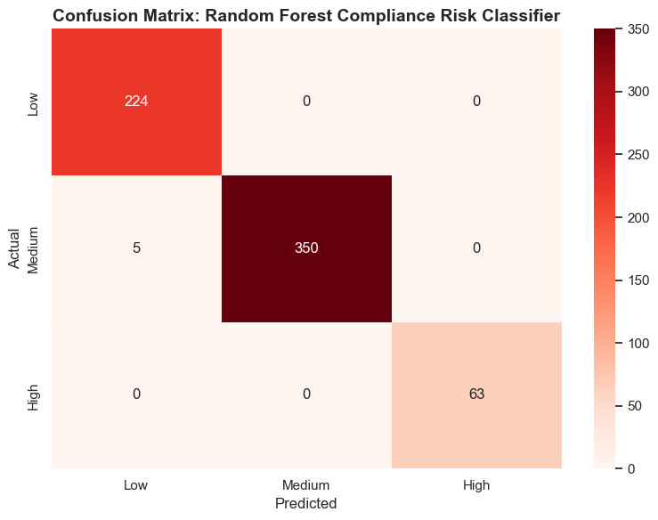

```python
# Random Forest confusion matrix
cm = confusion_matrix(y_test, y_pred, labels=['Low', 'Medium', 'High'])
plt.figure(figsize=(8, 6))
sns.heatmap(cm, annot=True, fmt='d', cmap='Reds',
            xticklabels=['Low', 'Medium', 'High'],
            yticklabels=['Low', 'Medium', 'High'])
plt.title('Confusion Matrix: Random Forest Compliance Risk Classifier',
          fontsize=14, fontweight='bold')
plt.xlabel('Predicted')
plt.ylabel('Actual')
plt.tight_layout()
plt.show()
```

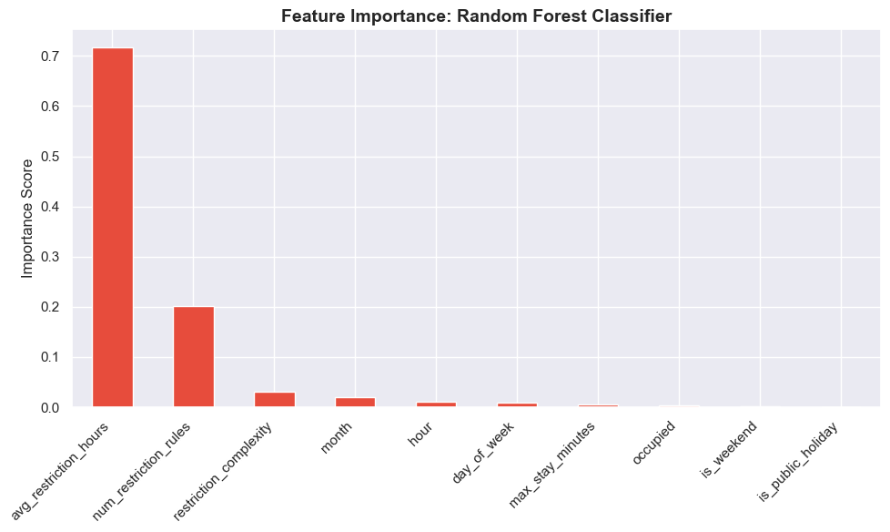

```python
# Feature importance
feat_importance = pd.Series(
    rf_model.feature_importances_, index=features).sort_values(ascending=False)

plt.figure(figsize=(10, 6))
feat_importance.plot(kind='bar', color='#e74c3c', edgecolor='white')
plt.title('Feature Importance: Random Forest Classifier',
          fontsize=14, fontweight='bold')
plt.ylabel('Importance Score')
plt.xticks(rotation=45, ha='right')
plt.tight_layout()
plt.show()
```

```
Logistic Regression Results:
              precision    recall  f1-score   support

        High       1.00      0.24      0.38        63
         Low       0.92      1.00      0.96       224
      Medium       0.88      0.95      0.92       355

    accuracy                           0.90       642
   macro avg       0.93      0.73      0.75       642
weighted avg       0.91      0.90      0.88       642
```

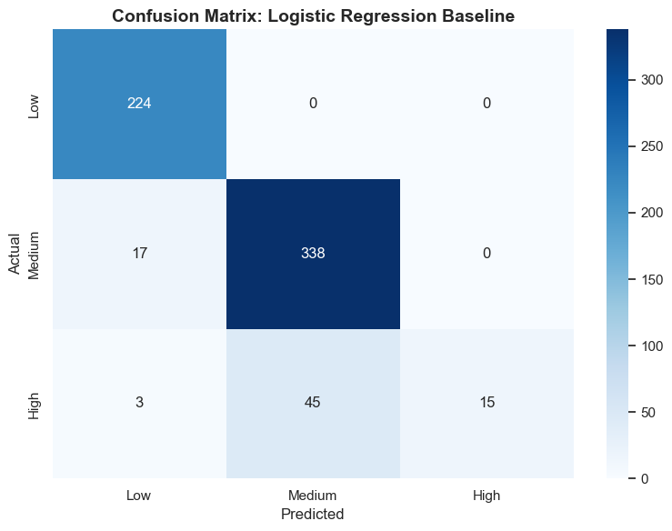

```python
# Logistic Regression baseline comparison
from sklearn.linear_model import LogisticRegression

lr_model = LogisticRegression(max_iter=1000, random_state=42)
lr_model.fit(X_train, y_train)
y_pred_lr = lr_model.predict(X_test)

print("Logistic Regression Results:")
print(classification_report(y_test, y_pred_lr))

cm_lr = confusion_matrix(y_test, y_pred_lr, labels=['Low', 'Medium', 'High'])
plt.figure(figsize=(8, 6))
sns.heatmap(cm_lr, annot=True, fmt='d', cmap='Blues',
            xticklabels=['Low', 'Medium', 'High'],
            yticklabels=['Low', 'Medium', 'High'])
plt.title('Confusion Matrix: Logistic Regression Baseline',
          fontsize=14, fontweight='bold')
plt.xlabel('Predicted')
plt.ylabel('Actual')
plt.tight_layout()
plt.show()
```

## Model Results Summary

Our Random Forest classifier achieved 99% accuracy across all three risk categories. Most importantly it correctly identified all High risk bays without a single misclassification in that category. This is critical for our use case because missing a High risk bay means missing a real problem area in the city.

The Logistic Regression baseline only achieved 90% accuracy and missed 75% of High risk bays, classifying them as Low or Medium instead. This confirms that Random Forest is the right choice for this problem.

Looking at feature importance, avg_restriction_hours and num_restriction_rules are by far the strongest predictors of compliance risk. This makes intuitive sense as bays with longer enforcement windows and more overlapping rules are genuinely more confusing and risky for drivers.

```python
# Adding risk scores to master
master['compliance_risk_score'] = master_risk['compliance_risk_score']
master['risk_category'] = master_risk['risk_category']

print("Risk scores added successfully")
print(f"\nRisk category distribution:")
print(master['risk_category'].value_counts())
print(f"\nSample of master with risk scores:")
print(master[['RoadSegmentDescription','Latitude','Longitude',
              'occupied','compliance_risk_score','risk_category']].head(10))
```

```
Risk scores added successfully

Risk category distribution:
risk_category
Medium    1760
Low       1120
High       329
Name: count, dtype: int64

Sample of master with risk scores:
                              RoadSegmentDescription   Latitude   Longitude  \
0  Southbank Boulevard between Sturt Street and M... -37.823382  144.966754
1  Little Lonsdale Street between Elizabeth Stree... -37.811627  144.960623
2  Little Lonsdale Street between Russell Street ... -37.809927  144.966361
3  Little Lonsdale Street between Russell Street ... -37.810352  144.964908
4  Little Lonsdale Street between Russell Street ... -37.810193  144.965637
5  Little Lonsdale Street between Russell Street ... -37.810232  144.965318
6  Little Lonsdale Street between Russell Street ... -37.810394  144.964947
7  Little Lonsdale Street between Elizabeth Stree... -37.811905  144.959674
8  Elizabeth Street between Queensberry Street an... -37.803117  144.958295
9  Nicholson Street between Spring Street and Alb... -37.810532  144.972948

   occupied  compliance_risk_score risk_category
0         0               0.224228        Medium
1         0               0.189419           Low
2         1               0.256019          High
3         0               0.256019          High
4         0               0.224228        Medium
5         0               0.224228        Medium
6         1               0.256019          High
7         1               0.189419           Low
8         0               0.144952           Low
9         1               0.144952           Low
```

## Building Our Compliance Risk Map

This is the main visual output of our project. We are plotting every parking bay in Melbourne CBD on an interactive map, colour coded by compliance risk level. Green means the bay is low risk and easy for drivers to use. Orange means medium risk with some complexity to the rules. Red means high risk where drivers are most likely to get confused or receive a fine. Clicking on any dot shows the street name, risk level, and key details about that bay.

```python
!pip install folium -q
```

```python
# Building our compliance risk map of Melbourne CBD
import folium

color_map = {'Low': 'green', 'Medium': 'orange', 'High': 'red'}
risk_desc = {
    'Low': 'Low Risk: Simple rules, easy to park here',
    'Medium': 'Medium Risk: Some restrictions to be aware of',
    'High': 'High Risk: Complex rules, high chance of a fine'
}

m = folium.Map(location=[-37.8136, 144.9631], zoom_start=14,
               tiles='CartoDB positron')

for _, row in master.iterrows():
    folium.CircleMarker(
        location=[row['Latitude'], row['Longitude']],
        radius=6,
        color=color_map[row['risk_category']],
        fill=True,
        fill_color=color_map[row['risk_category']],
        fill_opacity=0.8,
        popup=folium.Popup(
            f"<b>📍 {row['RoadSegmentDescription']}</b><br><br>"
            f"<b>Risk Level:</b> {row['risk_category']}<br>"
            f"<b>What this means:</b> {risk_desc[row['risk_category']]}<br><br>"
            f"<b>Currently:</b> {'🔴 Occupied' if row['occupied'] == 1 else '🟢 Free'}<br>"
            f"<b>Enforcement Hours:</b> {row['avg_restriction_hours']:.0f} hours per day<br>"
            f"<b>Number of Rules:</b> {int(row['num_restriction_rules'])} restriction rules<br>"
            f"<b>Risk Score:</b> {row['compliance_risk_score']:.2f} out of 1.0",
            max_width=280
        )
    ).add_to(m)

legend_html = '''
<div style="position: fixed; bottom: 30px; left: 30px; z-index: 1000;
            background-color: white; padding: 10px 15px; border-radius: 8px;
            border: 1.5px solid #ccc; font-size: 11px; font-family: Arial;">
    <b style="font-size:12px;">🅿️ Parking Risk Levels</b><br><br>
    <span style="color:green; font-size:13px;">●</span>
    <b>Low Risk</b>: Safe to park, simple rules<br><br>
    <span style="color:orange; font-size:13px;">●</span>
    <b>Medium Risk</b>: Check the signs carefully<br><br>
    <span style="color:red; font-size:13px;">●</span>
    <b>High Risk</b>: Complex rules, fine likely<br><br>
    <small>Click any dot for more details</small>
</div>
'''
m.get_root().html.add_child(folium.Element(legend_html))

title_html = '''
<div style="position: fixed; top: 10px; left: 50%; transform: translateX(-50%);
            z-index: 1000; background-color: white; padding: 6px 14px;
            border-radius: 6px; border: 1.5px solid #ccc; font-family: Arial;
            font-size: 13px; font-weight: bold; text-align: center;">
    🗺️ Melbourne CBD Parking Compliance Risk Map
</div>
'''
m.get_root().html.add_child(folium.Element(title_html))

display(m)
```

Make this Notebook Trusted to load map: File -> Trust Notebook

[interactive chart not shown]

## Important Note About the Map Data

One important thing to be transparent about is the occupancy status shown when you click on each bay. The Currently Occupied or Currently Free label does not reflect live real time data. Our sensor dataset is a snapshot, meaning each bay's status represents the last recorded reading at the time the data was collected from the City of Melbourne portal.

This is a known limitation of the dataset. A truly live version of this map would require a continuous sensor feed with real time API access which is beyond the scope of this project. What we have built is a risk indicator map rather than a live availability tracker. The compliance risk scores, restriction hours, and rule complexity shown for each bay are all based on real data and are accurate regardless of the occupancy snapshot limitation.

In a real world deployment this map could be connected to the City of Melbourne live parking API to show actual availability in real time.

## Zone Level Risk Summary

Here we are building a summary chart that ranks the top 15 road segments by average compliance risk score. This gives us a clear picture of which streets need the most attention and directly informs our recommendations around dynamic pricing, signage, and resource allocation.

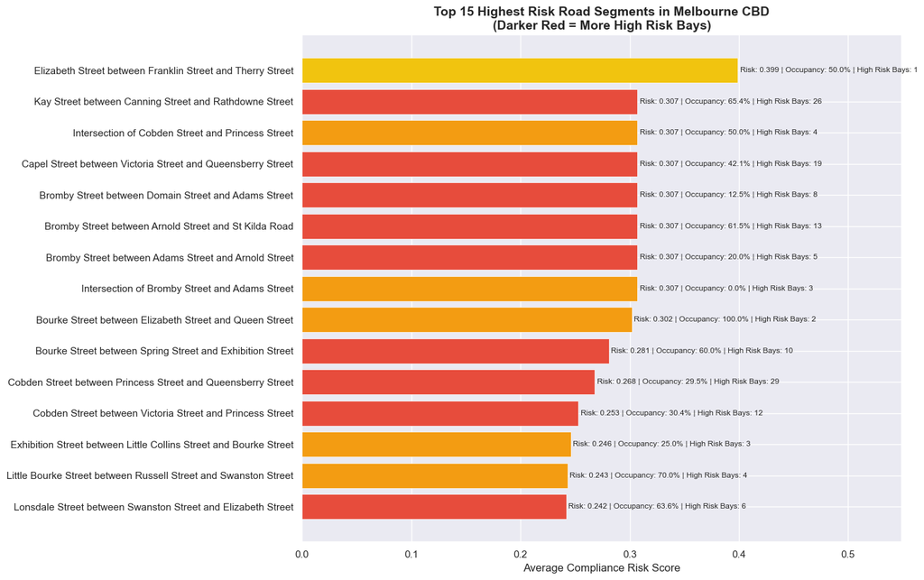

```
Top 15 Highest Risk Zones:
                                           RoadSegmentDescription  total_bays  occupancy_pct  avg_risk_score  high_risk_bays
       Elizabeth Street between Franklin Street and Therry Street           2           50.0           0.399               1
           Kay Street between Canning Street and Rathdowne Street          26           65.4           0.307              26
                Intersection of Cobden Street and Princess Street           4           50.0           0.307               4
      Capel Street between Victoria Street and Queensberry Street          19           42.1           0.307              19
             Bromby Street between Domain Street and Adams Street           8           12.5           0.307               8
            Bromby Street between Arnold Street and St Kilda Road          13           61.5           0.307              13
             Bromby Street between Adams Street and Arnold Street           5           20.0           0.307               5
                   Intersection of Bromby Street and Adams Street           3            0.0           0.307               3
          Bourke Street between Elizabeth Street and Queen Street           3          100.0           0.302               2
        Bourke Street between Spring Street and Exhibition Street          15           60.0           0.281              10
     Cobden Street between Princess Street and Queensberry Street          44           29.5           0.268              29
        Cobden Street between Victoria Street and Princess Street          23           30.4           0.253              12
Exhibition Street between Little Collins Street and Bourke Street           8           25.0           0.246               3
  Little Bourke Street between Russell Street and Swanston Street          10           70.0           0.243               4
     Lonsdale Street between Swanston Street and Elizabeth Street          11           63.6           0.242               6
```

```python
# Building our zone level risk summary
zone_summary = master.groupby('RoadSegmentDescription').agg(
    total_bays=('KerbsideID', 'count'),
    avg_occupancy=('occupied', 'mean'),
    avg_risk_score=('compliance_risk_score', 'mean'),
    high_risk_bays=('risk_category', lambda x: (x == 'High').sum()),
    medium_risk_bays=('risk_category', lambda x: (x == 'Medium').sum()),
    low_risk_bays=('risk_category', lambda x: (x == 'Low').sum()),
    avg_restriction_hours=('avg_restriction_hours', 'mean'),
    avg_restriction_rules=('num_restriction_rules', 'mean')
).reset_index()

zone_summary['occupancy_pct'] = (zone_summary['avg_occupancy'] * 100).round(1)
zone_summary['avg_risk_score'] = zone_summary['avg_risk_score'].round(3)
zone_summary = zone_summary.sort_values('avg_risk_score', ascending=False)

top15 = zone_summary.head(15).copy()

colors = ['#e74c3c' if r >= 5 else '#f39c12' if r >= 2 else '#f1c40f'
          for r in top15['high_risk_bays']]

fig, ax = plt.subplots(figsize=(14, 9))
bars = ax.barh(top15['RoadSegmentDescription'],
               top15['avg_risk_score'],
               color=colors, edgecolor='white', linewidth=0.5)

for bar, row in zip(bars, top15.itertuples()):
    ax.text(bar.get_width() + 0.002,
            bar.get_y() + bar.get_height()/2,
            f"Risk: {row.avg_risk_score:.3f} | "
            f"Occupancy: {row.occupancy_pct}% | "
            f"High Risk Bays: {int(row.high_risk_bays)}",
            va='center', fontsize=8.5)

ax.set_xlabel('Average Compliance Risk Score', fontsize=12)
ax.set_title('Top 15 Highest Risk Road Segments in Melbourne CBD\n'
             '(Darker Red = More High Risk Bays)',
             fontsize=14, fontweight='bold')
ax.invert_yaxis()
ax.set_xlim(0, top15['avg_risk_score'].max() + 0.15)
plt.tight_layout()
plt.show()

print("\nTop 15 Highest Risk Zones:")
print(zone_summary.head(15)[['RoadSegmentDescription','total_bays',
                              'occupancy_pct','avg_risk_score',
                              'high_risk_bays']].to_string(index=False))
```

## Off Street Supply Gap Analysis

Here we are identifying zones where on street parking is consistently full but off street car parks are available nearby. This is important because in many cases the supply is actually there, drivers just do not know about it or are not being directed to it. Fixing this with better signage or wayfinding could reduce congestion without needing to build new infrastructure.

```python
pip install geopandas
```

[output not shown]

[output cut: 32 more lines]

[output not shown]

```python
# Off street supply gap analysis
import geopandas as gpd
from shapely.geometry import Point

master_gdf = gpd.GeoDataFrame(
    master,
    geometry=gpd.points_from_xy(master.Longitude, master.Latitude),
    crs='EPSG:4326'
).to_crs('EPSG:28355')

offstreet_gdf = gpd.GeoDataFrame(
    offstreet_clean,
    geometry=gpd.points_from_xy(offstreet_clean.Longitude, offstreet_clean.Latitude),
    crs='EPSG:4326'
).to_crs('EPSG:28355')

master_gdf['buffer'] = master_gdf.geometry.buffer(400)

nearby_capacity = []
for _, row in master_gdf.iterrows():
    nearby = offstreet_gdf[offstreet_gdf.geometry.within(row['buffer'])]
    nearby_capacity.append(nearby['Parking spaces'].sum())

master_gdf['nearby_offstreet_capacity'] = nearby_capacity
master['nearby_offstreet_capacity'] = nearby_capacity

print(f"Average nearby off street capacity per bay: {master['nearby_offstreet_capacity'].mean():.0f} spaces")
print(f"Bays with zero nearby off street options: {(master['nearby_offstreet_capacity'] == 0).sum()}")
print(f"Bays with over 100 nearby off street spaces: {(master['nearby_offstreet_capacity'] > 100).sum()}")
```

```
Average nearby off street capacity per bay: 8085 spaces
Bays with zero nearby off street options: 0
Bays with over 100 nearby off street spaces: 3209
```

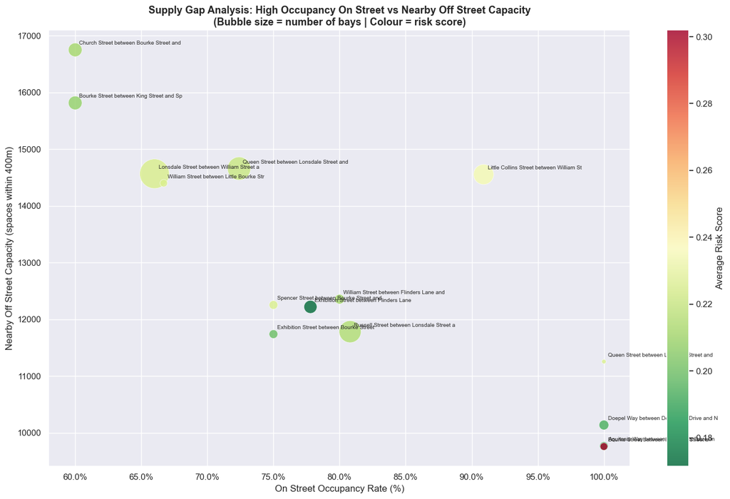

```
Top 10 Opportunity Zones (High Occupancy + Lots of Nearby Off Street):
                                         RoadSegmentDescription  occupancy_pct  avg_nearby_capacity  total_bays
   Little Collins Street between William Street and King Street           90.9              14554.0          22
      Queen Street between La Trobe Street and A'Beckett Street          100.0              11256.0           1
Queen Street between Lonsdale Street and Little Lonsdale Street           72.4              14658.0          29
       Doepel Way between Docklands Drive and Newquay Promenade          100.0              10138.0           5
  Church Street between Bourke Street and Little Collins Street           60.0              16750.0          10
        William Street between Flinders Lane and Collins Street           80.0              12356.0           5
         Aquitania Way between Docklands Drive and Caravel Lane          100.0               9766.0           4
        Bourke Street between Elizabeth Street and Queen Street          100.0               9759.0           3
         Lonsdale Street between William Street and King Street           66.0              14566.0          47
William Street between Little Bourke Street and Lonsdale Street           66.7              14400.0           3
```

```python
# Visualising the supply gap analysis
gap_analysis = master.groupby('RoadSegmentDescription').agg(
    avg_occupancy=('occupied', 'mean'),
    avg_nearby_capacity=('nearby_offstreet_capacity', 'mean'),
    avg_risk_score=('compliance_risk_score', 'mean'),
    total_bays=('KerbsideID', 'count')
).reset_index()

gap_analysis['occupancy_pct'] = (gap_analysis['avg_occupancy'] * 100).round(1)
gap_analysis['avg_nearby_capacity'] = gap_analysis['avg_nearby_capacity'].round(0)

gap_analysis['opportunity_score'] = (
    gap_analysis['avg_occupancy'] * gap_analysis['avg_nearby_capacity'] / 1000
)
gap_analysis = gap_analysis.sort_values('opportunity_score', ascending=False)

top_opportunity = gap_analysis.head(15)

fig, ax = plt.subplots(figsize=(14, 9))
scatter = ax.scatter(
    top_opportunity['occupancy_pct'],
    top_opportunity['avg_nearby_capacity'],
    s=top_opportunity['total_bays'] * 30,
    c=top_opportunity['avg_risk_score'],
    cmap='RdYlGn_r',
    alpha=0.8,
    edgecolors='white',
    linewidth=0.5
)

for _, row in top_opportunity.iterrows():
    ax.annotate(
        row['RoadSegmentDescription'][:40],
        (row['occupancy_pct'], row['avg_nearby_capacity']),
        fontsize=7,
        ha='left',
        va='bottom',
        xytext=(5, 5),
        textcoords='offset points'
    )

plt.colorbar(scatter, ax=ax, label='Average Risk Score')
ax.set_xlabel('On Street Occupancy Rate (%)', fontsize=12)
ax.set_ylabel('Nearby Off Street Capacity (spaces within 400m)', fontsize=12)
ax.set_title('Supply Gap Analysis: High Occupancy On Street vs Nearby Off Street Capacity\n'
             '(Bubble size = number of bays | Colour = risk score)',
             fontsize=13, fontweight='bold')
ax.xaxis.set_major_formatter(mtick.PercentFormatter())
plt.tight_layout()
plt.show()

print("\nTop 10 Opportunity Zones (High Occupancy + Lots of Nearby Off Street):")
print(gap_analysis.head(10)[['RoadSegmentDescription','occupancy_pct',
                               'avg_nearby_capacity','total_bays']].to_string(index=False))
```